# readme

### Please add alt text to your posts

Please add alt text (alternative text) to all of your posted graphics for `#TidyTuesday`.

Twitter provides [guidelines](https://help.twitter.com/en/using-twitter/picture-descriptions) for how to add alt text to your images.

The DataViz Society/Nightingale by way of Amy Cesal has an [article](https://medium.com/nightingale/writing-alt-text-for-data-visualization-2a218ef43f81) on writing *good* alt text for plots/graphs.

Penn State has an [article](https://accessibility.psu.edu/images/charts/) on writing alt text descriptions for charts and tables.

> Charts, graphs and maps use visuals to convey complex images to users. But since they are images, these media provide serious accessibility issues to colorblind users and users of screen readers. See the [examples on this page](https://accessibility.psu.edu/images/charts/) for details on how to make charts more accessible.

The `{rtweet}` package includes the [ability to post tweets](https://docs.ropensci.org/rtweet/reference/post_tweet.html) with alt text programatically.

Need a **reminder**? There are [extensions](https://chrome.google.com/webstore/detail/twitter-required-alt-text/fpjlpckbikddocimpfcgaldjghimjiik/related) that force you to remember to add Alt Text to Tweets with media.

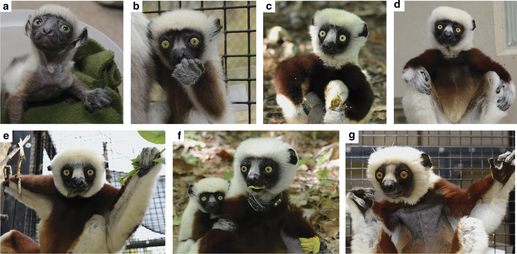

Figure 3: Propithecus coquereli life stages. - this image shows example images of the life stages of this species of lemur, progressing from young to old.

# Lemurs

The data this week comes from [Duke Lemur Center](https://lemur.duke.edu/) and was cleaned by [Jesse Mostipak](https://github.com/rfordatascience/tidytuesday/issues/204).

### About Lemurs and the Duke Lemur Center

> The [Duke Lemur Center](https://lemur.duke.edu/) houses over 200 lemurs across 14 species – the most diverse population of lemurs on Earth, outside their native Madagascar.

> Lemurs are the most threatened group of mammals on the planet, and 95% of lemur species are at risk of extinction. Our mission is to learn everything we can about lemurs – because the more we learn, the better we can work to save them from extinction. They are endemic only to Madagascar, so it’s essentially a one-shot deal: once lemurs are gone from Madagascar, they are gone from the wild.

> By studying the variables that most affect their health, reproduction, and social dynamics, the Duke Lemur Center learns how to most effectively focus [their conservation efforts](https://lemur.duke.edu/protect/overview-madagascar-conservation-programs/). And the more we learn about lemurs, the better we can educate the public around the world about just how amazing these animals are, why they need to be protected, and how each and every one of us can make a difference in their survival.

### Taxonomic Code

> You can use the following table for the taxonomic code, or retrieve it by registering for the [Duke Lemur Center Database here](https://duke.qualtrics.com/jfe/form/SV_cZMTHoHiAljNGXX?Q_JFE=qdg).

| **Taxon** | **Latin name** | **Common name** |
| --- | --- | --- |
| CMEAD | Cheirogaleus medius | Fat-tailed dwarf lemur |
| DMAD | Daubentonia madagascariensis | Aye-aye |
| EALB | Eulemur albifrons | White-fronted brown lemur |
| ECOL | Eulemur collaris | Collared brown lemur |
| ECOR | Eulemur coronatus | Crowned lemur |
| EFLA | Eulemur flavifrons | Blue-eyed black lemur |
| EFUL | Eulemur fulvus | Common brown lemur |
| EMAC | Eulemur macaco | Black lemur |
| EMON | Eulemur mongoz | Mongoose lemur |
| ERUB | Eulemur rubriventer | Red-bellied lemur |
| ERUF | Eulemur rufus | Red-fronted brown lemur |
| ESAN | Eulemur sanfordi | Sanford’s brown lemur |
| EUL | Eulemur Eulemur | hybrid |
| GMOH | Galago moholi | Mohol bushbaby |
| HGG | Hapalemur griseus griseus | Eastern lesser bamboo lemur |
| LCAT | Lemur catta | Ring-tailed lemur |
| LTAR | Loris tardigradus | Slender loris |
| MMUR | Mircocebus murinus | Gray mouse lemur |
| MZAZ | Mirza coquereli | Northern giant mouse lemur |
| NCOU | Nycticebus coucang | Slow loris |
| NPYG | Nycticebus pygmaeus | Pygmy slow loris |
| OGG | Otolemur garnettii garnettii | Northern greater galago |
| PCOQ | Propithecus coquereli | Coquerel’s sifaka |
| PPOT | Perodicticus potto | Potto |
| VAR | Varecia Varecia | hybrid |
| VRUB | Varecia rubra | Red ruffed lemur |
| VVV | Varecia variegata variegata | Black-and-white ruffed lemur |

### Open Source article

> For more in-depth information on this dataset, please see: [Life history profiles for 27 strepsirrhine primate taxa generated using captive data from the Duke Lemur Center](http://www.nature.com/articles/sdata201419)

### Authors & Citation

> Zehr, SM, Roach RG, Haring D, Taylor J, Cameron FH, Yoder AD. Life history profiles for 27 strepsirrhine primate taxa generated using captive data from the Duke Lemur Center. Sci. Data 1:140019 doi: 10.1038/sdata.2014.19 (2014).

> Header image Photo by [Anggit Rizkianto](https://unsplash.com/@anggit_mr?utm_source=unsplash&utm_medium=referral&utm_content=creditCopyText) on Unsplash

### Get the data here

```r
# Get the Data

# Read in with tidytuesdayR package
# Install from CRAN via: install.packages("tidytuesdayR")
# This loads the readme and all the datasets for the week of interest

# Either ISO-8601 date or year/week works!

tuesdata <- tidytuesdayR::tt_load('2021-08-24')
tuesdata <- tidytuesdayR::tt_load(2021, week = 35)

lemurs <- tuesdata$lemurs

# Or read in the data manually

lemurs <- readr::read_csv('https://raw.githubusercontent.com/rfordatascience/tidytuesday/main/data/2021/2021-08-24/lemurs.csv')
```

# `lemurs.csv`

[output not shown]